# **Panorama da inflação**

Os principais índices de inflação do Brasil, apontam em setembro de 2008 um avanço da inflação de em média **0.17%**. Com esse resultado, no ano a inflação acumula uma variação média positiva de **5.77%**, e em 12 meses uma variação média acumulada de **8.53%**.

[output not shown]

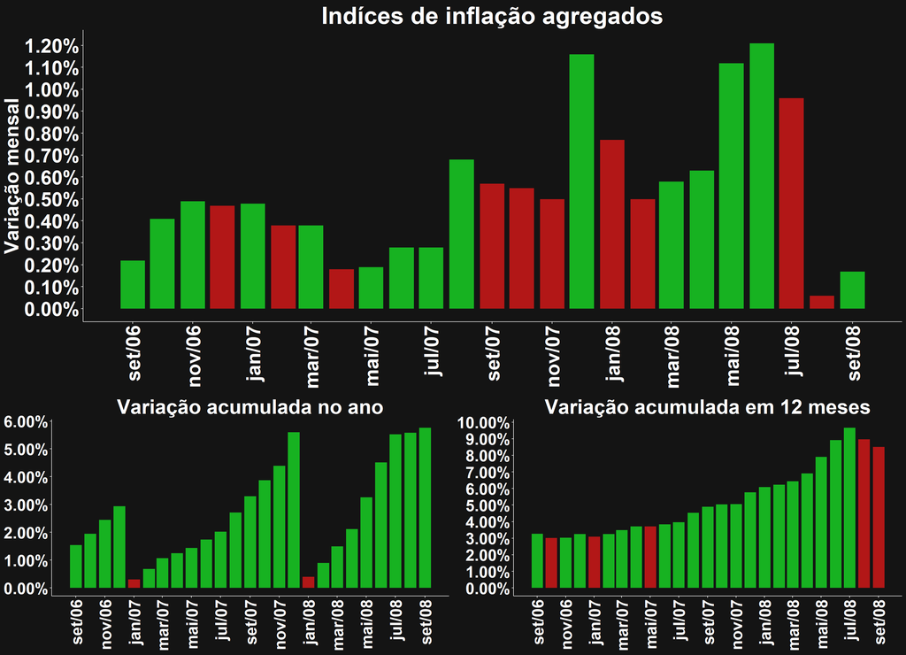

Índices selecionados para a média: IPCA, INPC e IGP-M.

# IPCA

O Indíce de Preços ao Consumidor Amplo (IPCA) variou 0.26% em setembro, valor superior ao mesmo período do ano anterior quando apresentou uma taxa de 0.18%. Com esse resultado o indíce acumula no ano uma variação positiva de 4.76%, e em 12 meses uma variação positiva de 6.25%.

|  | 09/2007 | 08/2008 | 09/2008 |
| --- | --- | --- | --- |
| Variação mensal | 0.18% | 0.28% | 0.26% |
| Variação acumulada no ano | 2.99% | 4.48% | 4.76% |
| Variação acumulada em 12 meses | 4.15% | 6.17% | 6.25% |

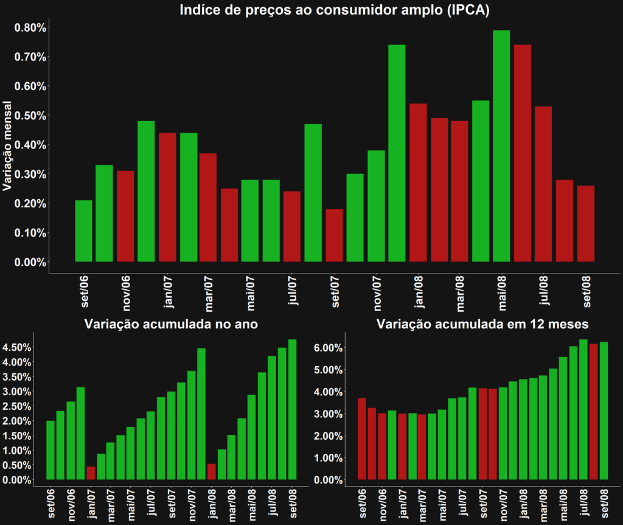

Os grupos que tiveram maior resultado positivo foram Despesas pessoais (0.8%) e Vestuário (0.7%), e negativo Alimentação e bebidas (-0.27%) e Comunicação (-0.12%).

|  | Variação mensal | Variação acumulada no ano | Peso mensal |
| --- | --- | --- | --- |
| Alimentação e bebidas | -0.27% | 9.29% | 22.77% |
| Habitação | 0.5% | 3.71% | 13.1% |
| Artigos de residência | 0.37% | 0.94% | 4.24% |
| Vestuário | 0.7% | 4.18% | 6.48% |
| Transportes | 0.39% | 2.35% | 19.88% |
| Saúde e cuidados pessoais | 0.46% | 4.77% | 10.75% |
| Despesas pessoais | 0.8% | 5.48% | 9.74% |
| Educação | -0.05% | 4.42% | 7.02% |
| Comunicação | -0.12% | 1.49% | 6.02% |

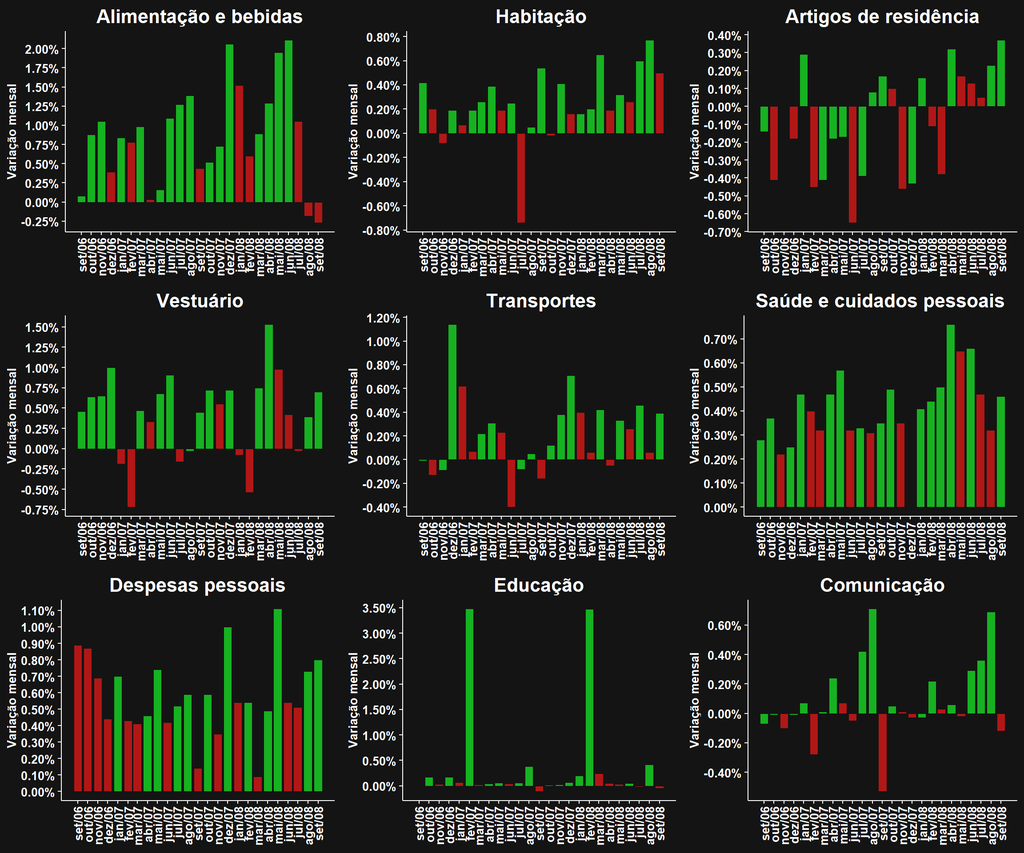

A nível de sub-itens os que mais influenciaram positivamente no resultado em relação ao seu peso foram Refeição (1.39%%) e Empregado doméstico (0.94%%), e negativamente Leite pasteurizado (-4.49%%) e Batata-inglesa (-13.76%%).

|  | Variação mensal | Variação acumulada no ano | Peso mensal |
| --- | --- | --- | --- |
| Cigarro | 3.17% | 5.66% | 0.84% |
| Refeição | 1.39% | 12.25% | 4.05% |
| Empregado doméstico | 0.94% | 7.93% | 3.15% |
| Gasolina | 0.69% | -0.2% | 4.23% |

|  | Variação mensal | Variação acumulada no ano | Peso mensal |
| --- | --- | --- | --- |
| Batata-inglesa | -13.76% | -18.7% | 0.2% |
| Tomate | -14.54% | 23.04% | 0.16% |
| Cebola | -17.24% | 37.88% | 0.15% |
| Leite pasteurizado | -4.49% | 1.46% | 1.03% |

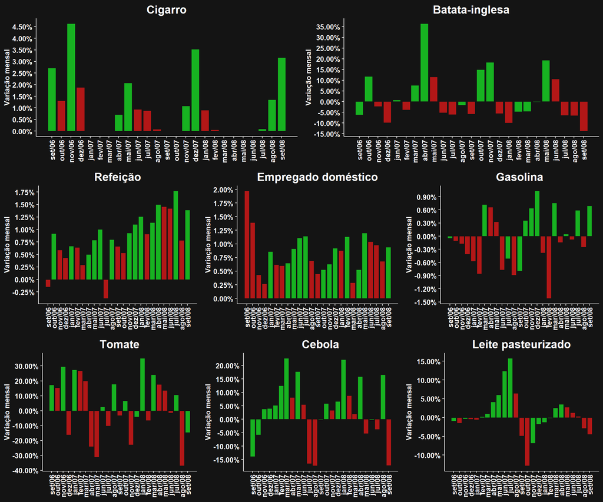

# INPC

|  | 09/2007 | 08/2008 | 09/2008 |
| --- | --- | --- | --- |
| Variação mensal | 0.25% | 0.21% | 0.15% |
| Variação acumulada no ano | 3.39% | 5.09% | 5.25% |
| Variação acumulada em 12 meses | 4.92% | 7.15% | 7.04% |

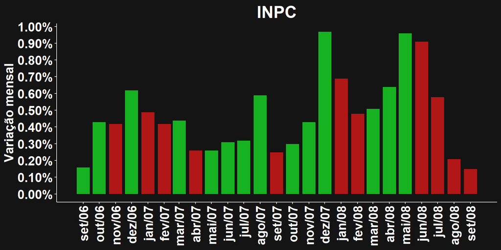

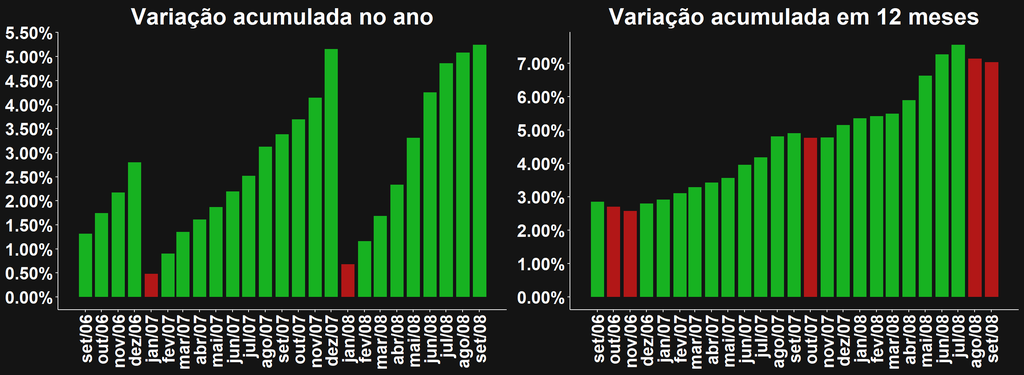

# IGP-M

|  | 09/2007 | 08/2008 | 09/2008 |
| --- | --- | --- | --- |
| Variação mensal | 1.29% | -0.32% | 0.11% |
| Variação acumulada no ano | 3.55% | 7.19% | 7.3% |
| Variação acumulada em 12 meses | 5.67% | 13.63% | 12.31% |

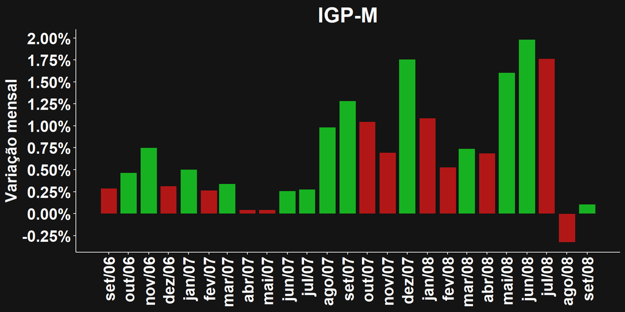

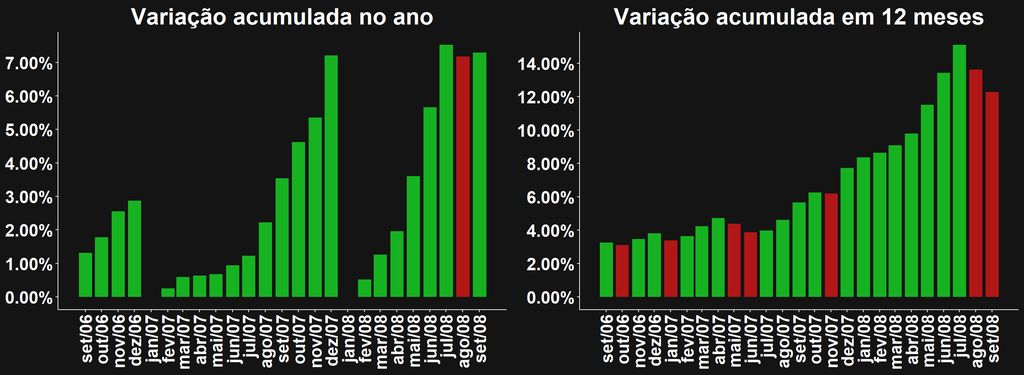

# IGP-DI

|  | 09/2007 | 08/2008 | 09/2008 |
| --- | --- | --- | --- |
| Variação mensal | 1.17% | -0.38% | 0.36% |
| Variação acumulada no ano | 4% | 6.88% | 7.27% |
| Variação acumulada em 12 meses | 6.16% | 12.8% | 11.9% |

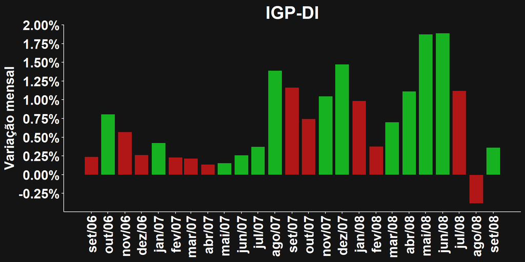

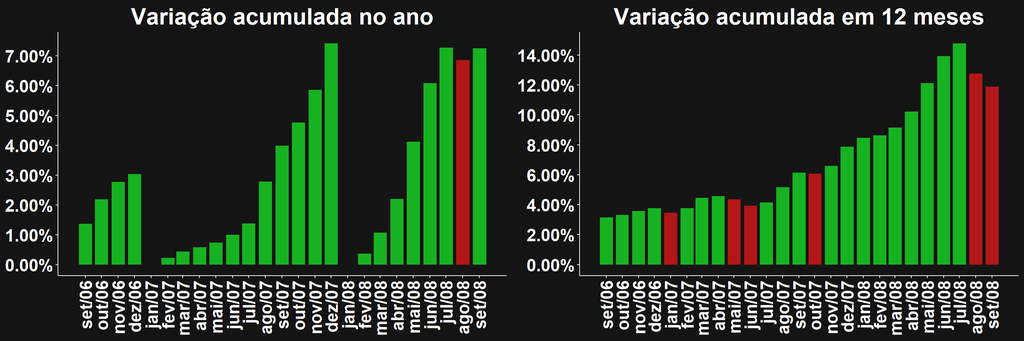

[output not shown]

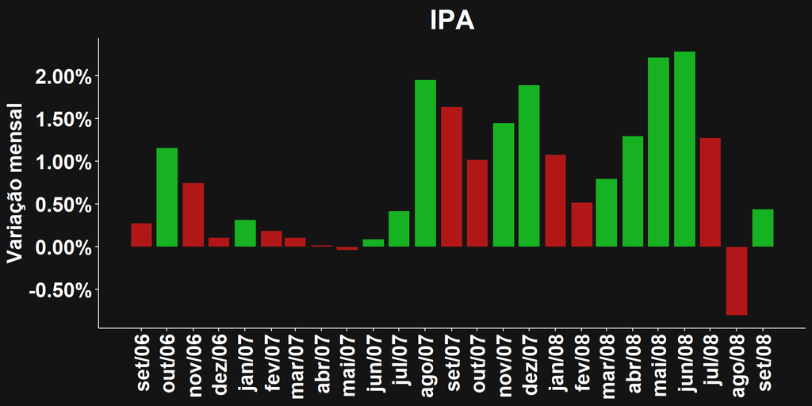

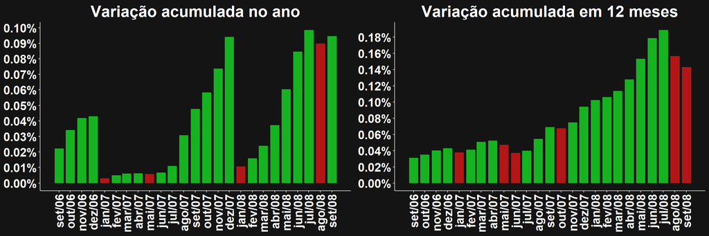

O Indíce de Preços ao Consumidor (IPC), integrante do IGP-DI com peso de 30%, apresentou variação de -0.09% em setembro, valor inferior ao mesmo período do ano anterior quando apresentou uma taxa de 0.23%. Com esse resultado o indíce acumula no ano uma variação positiva de 3.44%, e em 12 meses uma variação positiva de 5.6%.

|  | 09/2007 | 08/2008 | 09/2008 |
| --- | --- | --- | --- |
| Variação mensal | 0.23% | 0.14% | -0.09% |
| Variação acumulada no ano | 2.76% | 3.53% | 3.44% |
| Variação acumulada em 12 meses | 4.5% | 5.93% | 5.6% |

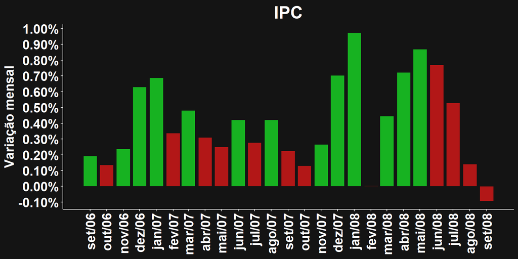

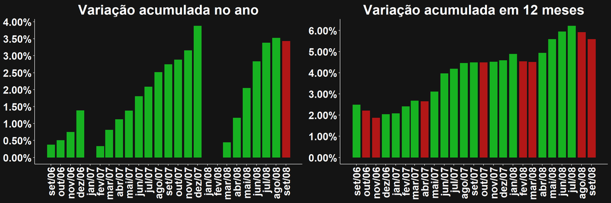

O Indíce Nacional de Custos de Construção (INCC), integrante do IGP-DI com peso de 10%, apresentou variação de 0.95% em setembro, valor superior ao mesmo período do ano anterior quando apresentou uma taxa de 0.51%. Com esse resultado o indíce acumula no ano uma variação positiva de 9.86%, e em 12 meses uma variação positiva de 11.88%.

|  | 09/2007 | 08/2008 | 09/2008 |
| --- | --- | --- | --- |
| Variação mensal | 0.51% | 1.18% | 0.95% |
| Variação acumulada no ano | 4.16% | 8.83% | 9.86% |
| Variação acumulada em 12 meses | 5.46% | 11.4% | 11.88% |

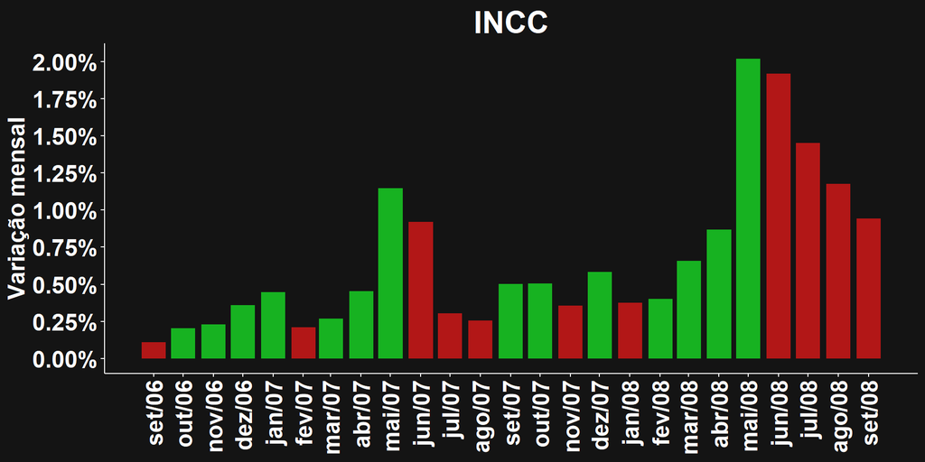

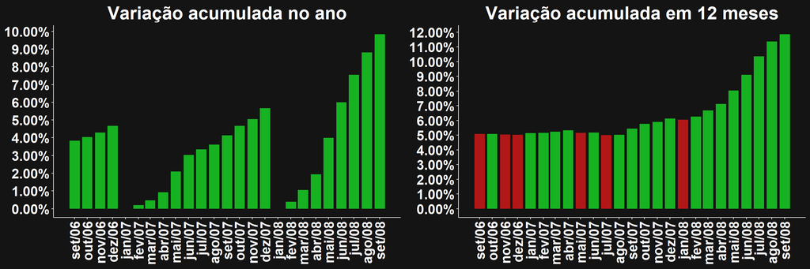

# Estatísticas

As estatísticas descritivas a seguir são feitas com base nos últimos 48 meses, e tem como objetivo possibilitar a avaliação do resultado observado em comparação aos períodos anteriores.

|  | Minimo | 1 Quartil | Mediana | Media | 3 Quartil | Maximo | Desvio Padrão |
| --- | --- | --- | --- | --- | --- | --- | --- |
| IPCA | -0.21% | 0.26% | 0.42% | 0.41% | 0.55% | 0.87% | 0.23% |
| INPC | -0.11% | 0.2% | 0.42% | 0.4% | 0.58% | 0.97% | 0.27% |
| IGP-M | -0.65% | 0.09% | 0.39% | 0.47% | 0.77% | 1.98% | 0.6% |
| IGP-DI | -0.79% | 0.17% | 0.39% | 0.47% | 0.76% | 1.89% | 0.57% |
| IPA | -1.04% | 0.06% | 0.43% | 0.49% | 1.03% | 2.29% | 0.81% |
| IPC | -0.44% | 0.13% | 0.34% | 0.35% | 0.63% | 0.97% | 0.33% |
| INCC | 0.02% | 0.27% | 0.45% | 0.62% | 0.79% | 2.09% | 0.5% |

Levando em consideração o desvio padrão de cada indíce, proporcionalmente os que mais se afastaram da média foram o IPC, o INPC e o INCC.

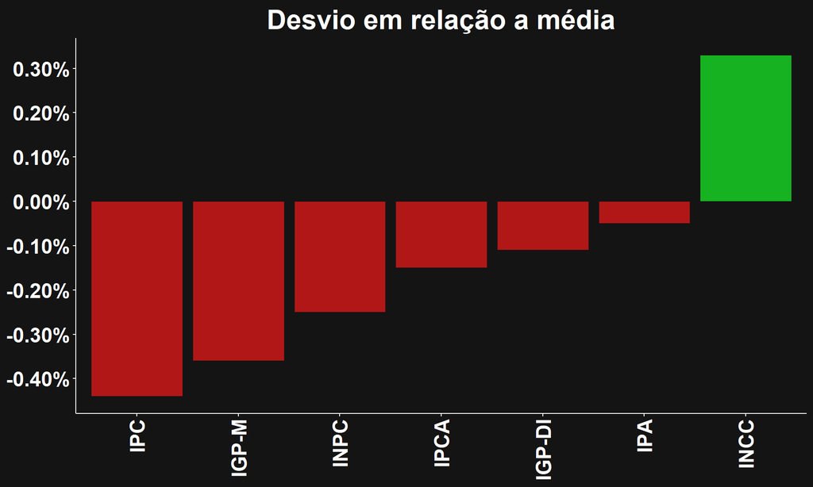

**João Victor Gomes**  
**jvg.santana@gmail.com**  
**[linkedin.com/in/jvictorgomes](https://www.linkedin.com/in/jvictorgomes/)**